# Modelling Water Flow with Shrinkage Methods

Rage Against The Machine Learning

31/01/2021

# Introduction

## Water Flow and Water Level

Statistical prediction of water flow (norsk: vannføring) and water level (norsk: vannstand) in rivers is an increasingly important problem. The problem is tightly linked with the prediction of floods. Because of climate change, the occurrence of floods is predicted to increase, and possibly in areas where floods have been historically rare:

[(Norwegian) Klima, nå og i framtiden](https://www.nve.no/klima/klima-na-og-i-framtiden/?ref=mainmenu)

Floods are potentially deadly for both humans and wildlife, and have huge economic consequences each year. Rivers are also an extremely important resource in many countries. In Norway, 90 % of produced electricity comes from hydropower:

[(Norwegian) Kraftproduksjon](https://energifaktanorge.no/norsk-energiforsyning/kraftforsyningen/)

Good statistical models for water discharge and water level are important in order to optimize the production of electricity. The *Norwegian Water Resources and Energy Directorate (NVE)* has about 600 water level measurement stations all over Norway:

[(Norwegian) Stasjonsnettet](https://www.nve.no/hydrologi/vannstand-og-vannforing/stasjonsnettet/)

Measurements are going as far back as the 1940’s. The *Norwegian Meteorological Institute (MET)* is responsible for the developed weather measurement and forecasting infrastructure in Norway. Many variables obtained by weather measurements, such as temperature, percipitation and snow content are traditionally used in physical models for water discharge and water level. These physical models usually require parameter fitting and/or field experiments in order to yield good predictions. With the wealth of data available, it is worth considering purely data-driven approaches using measurements from NVE and MET to predict water discharge and water level. In this report we will attempt to apply statistical shrinkage models to predict water discharge at Eggafossen in Trøndelag, Norway. NVE was kind enough to give us water measurements and predictions from the model they are currently using, as well as weather data obtained from MET.

## Eggafossen

Eggafossen is a location along the Gaula river in Trøndelag. Gaula as a whole is approximately 153 kilometers long and drains a watershed of about 3,661 square kilometres. The river runs through several populated areas as well as along the county road fv30, the highway E6 and the Rørosbanen train rail.

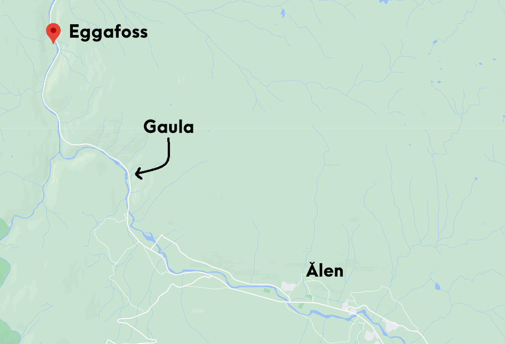

Source: Google maps

## The HBV model

Because the HBV model most likely requires a data-driven fitting process, it is worth asking: Is it possible to make comparable predictions to the HBV model using a purely data-driven model? The data driven model would have access to the same data as the HBV model. If a purely data-driven model is shown to be as good or nearly as good as the HBV model, the model can easily be transferred to other measurement stations. Furthermore, data-driven models can be used for inference in order to assess what actually causes discharge, and can be used for confidence intervals and uncertainty measurements more easily than a physical model.

# Exploring the Data

The data from various csv-files from NVE is gathered into the file `raw_data_eggafoss.rds`.

```r
# Importing data from Eggafoss
eggafoss = readRDS("data/raw_data_eggafoss.rds")

# Transform column names
names(eggafoss)[6:8] <- c("vannføring", "vannstand", "modellertvannføring")
names(eggafoss)
```

```
## [1] "dato"                "nedbør"              "snødekningsgrad"
## [4] "snøvannekvivalent"   "temperatur"          "vannføring"
## [7] "vannstand"           "modellertvannføring"
```

The data set consists of 8 features. They are all measured at 12:00 at the date of measurement.

- `dato`: date of measurements [yyyy-mm-dd]
- `nedbør`: rainfall [m]
- `snødekningsgrad`: snow coverage [%]
- `snøvannekvivalent`: snow’s water equivalent [m]
- `temperatur`: temperature [°C]
- `vannføring`: water flow in river [m³/s]
- `vannstand`: water level in river [m]
- `modellertvannføring`: HBV’s modelled water flow [m³/s]

As discussed above, we will use `vannføring` as the response, while the other features will become the predictors. We begin by gauging basic information about the data.

```r
str(eggafoss)
```

```
## Classes 'data.table' and 'data.frame':   28764 obs. of  8 variables:
##  $ dato               : Date, format: "1941-04-01" "1941-04-02" ...
##  $ nedbør             : num  NA NA NA NA NA NA NA NA NA NA ...
##  $ snødekningsgrad    : num  NA NA NA NA NA NA NA NA NA NA ...
##  $ snøvannekvivalent  : num  NA NA NA NA NA NA NA NA NA NA ...
##  $ temperatur         : num  NA NA NA NA NA NA NA NA NA NA ...
##  $ vannføring         : num  NA NA NA NA 1.37 ...
##  $ vannstand          : num  0 0 0 0 1.28 1.27 1.27 1.27 1.3 1.35 ...
##  $ modellertvannføring: num  NA NA NA NA NA NA NA NA NA NA ...
##  - attr(*, ".internal.selfref")=<externalptr>
##  - attr(*, "sorted")= chr "dato"
```

```r
summary(eggafoss)
```

```
##       dato                nedbør      snødekningsgrad  snøvannekvivalent
##  Min.   :1941-04-01   Min.   :0.000   Min.   :  0.00   Min.   :0.000
##  1st Qu.:1960-12-07   1st Qu.:0.000   1st Qu.:  0.10   1st Qu.:0.000
##  Median :1980-08-15   Median :0.001   Median : 99.90   Median :0.093
##  Mean   :1980-08-15   Mean   :0.003   Mean   : 61.83   Mean   :0.175
##  3rd Qu.:2000-04-23   3rd Qu.:0.004   3rd Qu.:100.00   3rd Qu.:0.317
##  Max.   :2019-12-31   Max.   :0.090   Max.   :100.00   Max.   :0.994
##                       NA's   :6119    NA's   :6119     NA's   :6119
##    temperatur        vannføring        vannstand     modellertvannføring
##  Min.   :-39.500   Min.   :  0.443   Min.   :0.000   Min.   :  0.000
##  1st Qu.: -5.320   1st Qu.:  2.731   1st Qu.:1.440   1st Qu.:  1.383
##  Median :  0.490   Median :  6.665   Median :1.700   Median :  8.661
##  Mean   :  0.211   Mean   : 17.731   Mean   :1.826   Mean   : 18.622
##  3rd Qu.:  6.730   3rd Qu.: 19.089   3rd Qu.:2.110   3rd Qu.: 19.771
##  Max.   : 21.070   Max.   :394.590   Max.   :3.930   Max.   :248.964
##  NA's   :6119      NA's   :4                         NA's   :6119
```

We notice that `dato` is given in Date-format, while the other feaures are numerical. Most features, like `nedbør`, `snødekningsgrad`, `vannføring`, `vannstand` og `modellertvannføring`, takes on numerical values greater or equal to zero, while `temperatur` can attain negative values as well. `snødekningsgrad` is given in percent, so its range is between 0 and 100. The `dato` column shows that the collection of the data started in 1941 and goes all the up to the end of 2019, which means we have 78 years of daily data for some of our features. There also seems to be a lot of missing values is the dataset, which we will deal with below.

# Preprocessing and Exploratory Data Analysis

Before we can start fitting our data to different models, we have to preprosess the data and do some exploratory data analysis. The goal of this is making sure we have no missing values and that the data is transformed the way we want it, as well as get a initial feel for the features and their correlation with the response and with each other.

## Handeling Missing values

From the summary of the data above, we see that we are missing some values. We make a plot of the missing values to see just how much we are missing.

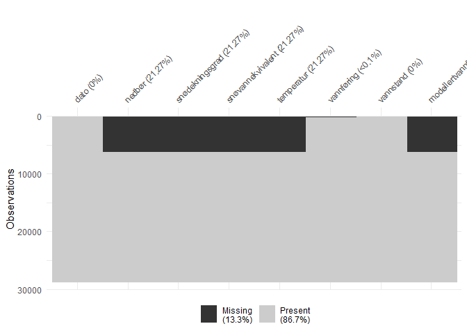

```r
naniar::vis_miss(eggafoss)
```

We see that we are only missing data for a certain range of dates. From 1941 to 1958 we only have data on `vannføring` and `vannstand`, but nothing else. Since there is not much use predicting `vannføring` only from `vannstand` before 1958, we decide to remove these years from the dataset.

```r
# Remove data between 1941 and 1958
eggafoss = eggafoss[6120:28764, ]

# Any NA's left?
any(is.na(eggafoss))
```

```
## [1] FALSE
```

After removing the missing data we are left with 22645 observations from Eggafoss, which includes daily data from January 1st 1958 to December 31st 2019.

```r
dim(eggafoss)
```

```
## [1] 22645     8
```

```r
head(eggafoss)
```

```
##          dato nedbør snødekningsgrad snøvannekvivalent temperatur vannføring
## 1: 1958-01-01  0.000             100             0.252     -21.25      2.765
## 2: 1958-01-02  0.000             100             0.252     -30.54      2.575
## 3: 1958-01-03  0.003             100             0.256     -27.34      2.473
## 4: 1958-01-04  0.000             100             0.256     -29.02      2.416
## 5: 1958-01-05  0.000             100             0.256     -22.90      2.387
## 6: 1958-01-06  0.000             100             0.256     -10.44      2.359
##    vannstand modellertvannføring
## 1:      1.44               1.292
## 2:      1.43               1.187
## 3:      1.41               1.088
## 4:      1.41               0.998
## 5:      1.41               0.915
## 6:      1.40               0.839
```

## Examining Correlation

Now that we have removed all the missing values, we start exploring some of the underlying features of the data. We start by looking at the correlation between the covariates and the response.

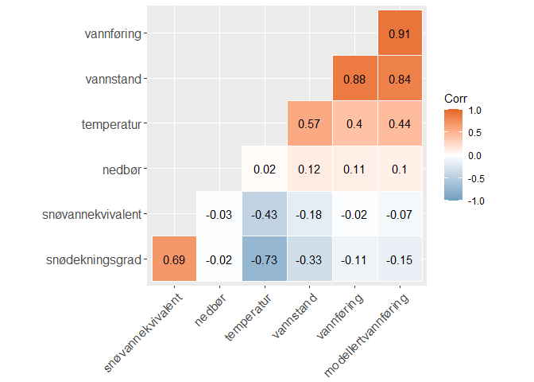

```r
# Calculate the correlation between the features
corr = cor(eggafoss[, 2:8])

# Plot the correlation
ggcorrplot(corr, hc.order = TRUE, type = "lower", lab = TRUE,
   outline.col = "white",
   ggtheme = ggplot2::theme_gray,
   colors = c("#6D9EC1", "white", "#E46726"))
```

We see that the response `vannføring` is mostly corrolated with `modellertvannføring` and `vannstand`. We make a scatterplot of both of them against the response to see in more detail how they affect each other. To avoid to many points at once, we sample 3000 points from our data so that the underlying structure of the data becomes clearer.

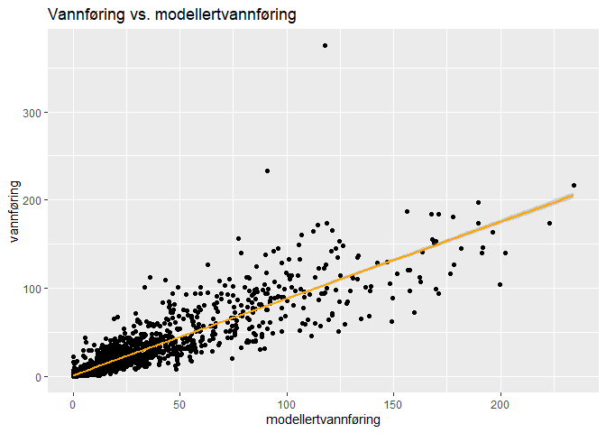

```r
# Extract 5000 samples
eggafoss_sample <- eggafoss[sample(nrow(eggafoss), 3000), ]

# Plot vannføring vs. modellertvannføring
ggplot(data = eggafoss_sample, aes(x = modellertvannføring, y = vannføring)) +
  geom_point() +
  geom_smooth(colour = "orange", method = "lm") +
  labs(title = "Vannføring vs. modellertvannføring")
```

We see that `vannføring` and `modellertvannføring` are highly correlated, which is no big surprise since `modellertvannføring` is in fact the predicted value of `vannføring` from the HBV model. Thus it does not make sense for us to include this feature in our model. We will rather use the results from the HBV model as a baseline for the results from our own model, and see if we can improve on their results.

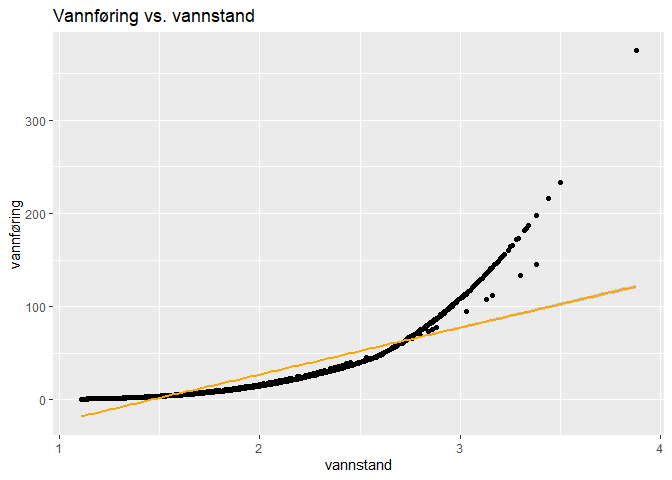

```r
# Plot vannføring vs. vannstand
ggplot(data = eggafoss_sample, aes(x = vannstand, y = vannføring)) +
  geom_point() +
  geom_smooth(colour = "orange", method = "lm") +
  labs(title = "Vannføring vs. vannstand")
```

The height of water in a river is intuitively correlated with the amount of water flow in the river. Low water level, low water flow, and vica versa. We see that the relationship is not linear, but looks more like like an exponential or quadratic function. Using `vannstand` to predict `vannføring` is a little bit problematic from a practical point of view. If we want to model the predicted water flow in a river, we most likely would not have any measurements of the water level that day. The other features, like `temperatur` and `snødekningsgrad` could be infered from good weather forcasting models, and thus would not pose the same practical problems. We conclude that when predicting the response, `vannstand` from the same day as the prediction will not be used.

We will also plot some of the covariates which have a high correlation with each other. This type of multicollinearity can cause problems in regular linear regression models, as it increases the standard error of the coefficients and thus some of the covariates can seem unsignificant, even though they are not. For the type of shrinkage methods we will use in this project, this multicollinearity will cause no problem, as the extra regularization term will regulate the size of the coefficients.

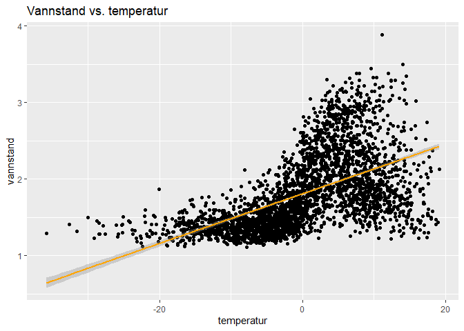

```r
# Plot vannstand vs. temperatur
ggplot(data = eggafoss_sample, aes(x = temperatur, y = vannstand)) +
  geom_point() +
  geom_smooth(colour = "orange", method = "lm") +
  labs(title = "Vannstand vs. temperatur")
```

We see that there is a positive trend between `vannstand` and `temperature`. It is most clear in the temperature interval between -10 and 5. This can indicate that `vannstand` is seasonal-dependend, and that a high water level occurs in the spring.

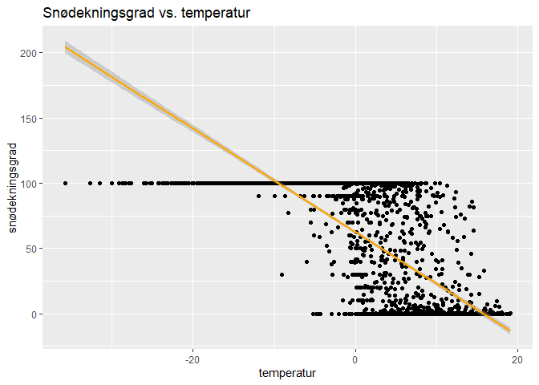

```r
# Plot temperatur vs. snødekningsgrad
ggplot(data = eggafoss_sample, aes(x = temperatur, y = snødekningsgrad)) +
  geom_point() +
  geom_smooth(colour = "orange", method = "lm") +
  labs(title = "Snødekningsgrad vs. temperatur")
```

We see that there is a negative correlation between `snødekningsgrad` and `temperature`, which again hints at a seasonal pattern. Below -10°C the snow coverage is at 100%. It starts decreasing once the temperature increases and winter becomes summer.

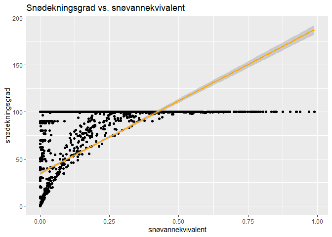

```r
# Plot snødekningsgrad vs. snøvannekvivalent
ggplot(data = eggafoss_sample, aes(x = snøvannekvivalent, y = snødekningsgrad)) +
  geom_point() +
  geom_smooth(colour = "orange", method = "lm") +
  labs(title = "Snødekningsgrad vs. snøvannekvivalent")
```

Between `snødekningsgrad` and `snøvannekvivalent` we see that there is somewhat of a linear relationship. The more snow covers the ground, the more water is produced when the show melts. Since `snødekningsgrad` only gives us the percentage of the ground covered by snow, it stops at 100%, and thus will not give us a good indication of how much snow there actually is on the ground. `snøvannekvivalent` can provide a better measure of this. Since the values are so similar, both might not be needed in our model, and might be removed, or set close to zero, by the shrinkage methods.

## Understanding the Seasonality of the Response

One of the features of our original data set is `dato`, the date at which each observation is measured. We cannot use this feature directly in building our model, but based on the analysis above, it might be beneficial to add some information about the time of each measurement, as seasonality is present in the data. To make an even stronger argument of this we look the response `vannføring` as a time series.

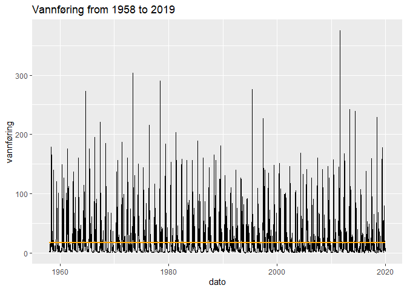

```r
# Time series of vannføring
ggplot(data = eggafoss, aes(x = dato, y = vannføring)) +
  geom_line() +
  geom_smooth(colour = "orange", method = "lm") +
  labs(title = "Vannføring from 1958 to 2019")
```

From the plot above we see that there is definitely some trends in the data that repeats yearly. We take a closer look by plotting some of the year on top of each other.

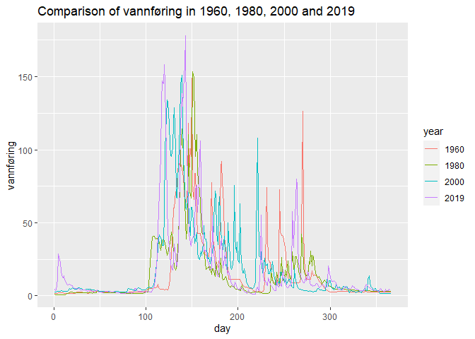

```r
years = c(1960, 1980, 2000, 2019)

eggafoss %>%
  dplyr::mutate(year = factor(lubridate::year(dato))) %>%
  dplyr::filter(year %in% years) %>%
  ggplot() +
  geom_line(aes(x = lubridate::yday(dato), y = vannføring, group = year, col = year)) +
  ggtitle("Comparison of vannføring in 1960, 1980, 2000 and 2019") +
  xlab("day")
```

We see that for the different years, a lot of the same trends are prevalent. During the winter month the water flow is usually very low, while during the spring and fall it increases dramatically. We make a boxplot of the `vannføring` for the different months:

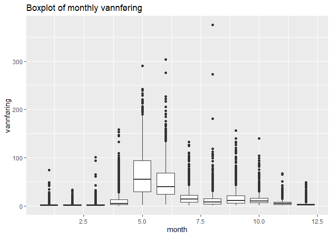

```r
eggafoss %>%
  ggplot() +
  geom_boxplot(aes(group = lubridate::month(dato), x = lubridate::month(dato), y = vannføring)) +
  ggtitle("Boxplot of monthly vannføring") +
  xlab("month")
```

Based on the plot above we make an argument that an interesting covariate to add to our model is `month`, which gives information about which month the observaion is from. We could also have chosen to include season instead of month, but because of the diffuculty to divide the pattern we see into seasons we might loose some information, and instead choose to do the finer monthly division. Adding more variables than necessary should not be a problem in this project, as the regularization methods will remove the variables which are not significant for the prediction of the response.

## Adding information about previous days

We will attempt to model the response as
$$f_n(t_{k+1}) = \beta_0 + \sum_{i = 1, i \neq n}^N \beta_i f_i(t_{k+1}) + \sum_{i =1}^N\sum_{j = 1}^d \beta_{(N-1)(1+i) + j}f_i(t_{k + 1 - j}),$$
where $f_n(t_{k+1})$ is the value of covariate $n$ at time $t_{k+1}$. The response `vannføring` is a linear model of other covariates on the same day (precipitation, temperature, snow) and the covariates including the response for the previous days. This way our model will capture not only the relevant paramters from the same day (assuming we have a good weather forecast, so precipitation, temperature and snow is known), but relevant parameters from previous days. The motivation behind this approach is that, for rivers, we would expect the water discharge to exhibit some delay in the response of the other covariates. For example, a heavy rainfall might lead to large water discharge after a couple of days as it takes time for the rainfall to travel through the soil into the river. In addition, we would expect a large change in snow (melting) will lead to large water discharge when this melted water reaches the river.

We want to emphasize that a linear model might not be the best way to model the response in this example, but as the problem will include a lot of covariates, some of which are highly correlated, it makes a great case study for the shrinkage methods.

```r
# Function which does all of the data preparation
# It does not scale or center the variables

data_preparation = function(df, years, days) {

  # Only include specified years + 1 year for testing
  df = df %>% dplyr::filter(format(dato, "%Y") > (2019-years-3))

  # Which covariates we want to include
  doVannstand = FALSE
  doVannføring = TRUE
  doSnøvannekvivalent = TRUE
  doSnødekningsgrad = TRUE
  doNedbør = TRUE
  doTemperatur = TRUE

  sumDo = doVannstand + doSnøvannekvivalent + doSnødekningsgrad +
    doNedbør + doTemperatur + doVannføring
  names = length(names(df))

  # Extract information about previous days
  for (i in 1:days){
    len = length(df$dato)
    if (i == 1){
      do = 0
      if (doVannstand) {
        do = do + 1
        data = data.frame(c(NA,df$vannstand[1:(len-1)]))
        df = data.frame(c(df, data))
        name = paste("vannstand",i,"dager",sep="")
        names(df)[names+do] = name
      }
      if (doSnøvannekvivalent) {
        do = do + 1
        data = data.frame(c(NA,df$snøvannekvivalent[1:(len-1)]))
        df = data.frame(c(df, data))
        name = paste("snøvannekvivalent",i,"dager",sep="")
        names(df)[names+do] = name
      }
      if (doSnødekningsgrad) {
        do = do + 1
        data = data.frame(c(NA,df$snødekningsgrad[1:(len-1)]))
        df = data.frame(c(df, data))
        name = paste("snødekningsgrad",i,"dager",sep="")
        names(df)[names + do] = name
      }
      if (doNedbør) {
        do = do + 1
        data = data.frame(c(NA,df$nedbør[1:(len-1)]))
        df = data.frame(c(df, data))
        name = paste("nedbør",i,"dager",sep="")
        names(df)[names + do] = name
      }
      if (doTemperatur) {
        do = do + 1
        data = data.frame(c(NA,df$temperatur[1:(len-1)]))
        df = data.frame(c(df, data))
        name = paste("temperatur",i,"dager",sep="")
        names(df)[names + do] = name
      }
      if (doVannføring) {
        do = do + 1
        data = data.frame(c(NA,df$vannføring[1:(len-1)]))
        df = data.frame(c(df, data))
        name = paste("vannføring",i,"dager",sep="")
        names(df)[names + do] = name
      }
    }
    else {
      do = 0
      if (doVannstand) {
        do = do + 1
        data = data.frame(c(NA,df[1:(len-1), names + (i-2)*sumDo + do]))
        df = data.frame(c(df, data))
        name = paste("vannstand",i,"dager",sep="")
        names(df)[names+(i-1)*sumDo + do] = name
      }
      if (doSnøvannekvivalent) {
        do = do + 1
        data = data.frame(c(NA,df[1:(len-1), names + (i-2)*sumDo + do]))
        df = data.frame(c(df, data))
        name = paste("snøvannekvivalent",i,"dager",sep="")
        names(df)[names+(i-1)*sumDo + do] = name
      }
      if (doSnødekningsgrad) {
        do = do + 1
        data = data.frame(c(NA,df[1:(len-1), names + (i-2)*sumDo + do]))
        df = data.frame(c(df, data))
        name = paste("snødekningsgrad",i,"dager",sep="")
        names(df)[names+(i-1)*sumDo + do] = name
      }
      if (doNedbør) {
        do = do + 1
        data = data.frame(c(NA,df[1:(len-1), names + (i-2)*sumDo + do]))
        df = data.frame(c(df, data))
        name = paste("nedbør",i,"dager",sep="")
        names(df)[names+(i-1)*sumDo + do] = name
      }
      if (doTemperatur) {
        do = do + 1
        data = data.frame(c(NA,df[1:(len-1), names + (i-2)*sumDo + do]))
        df = data.frame(c(df, data))
        name = paste("temperatur",i,"dager",sep="")
        names(df)[names+(i-1)*sumDo + do] = name
      }
      if (doVannføring) {
        do = do + 1
        data = data.frame(c(NA,df[1:(len-1), names + (i-2)*sumDo + do]))
        df = data.frame(c(df, data))
        name = paste("vannføring",i,"dager",sep="")
        names(df)[names+(i-1)*sumDo + do] = name
      }
    }
  }

  # Remove the first days of the dataset where we don't have values for all the covariates
  df = na.omit(df)

  # Add month variable as factor
  df = df %>%
    dplyr::mutate(df, month = lubridate::month(dato))
  df$month = as.factor(df$month)

  # Make dummy variables
  df = fastDummies::dummy_cols(df, select_columns = "month",
                               remove_first_dummy = TRUE,
                               remove_selected_columns = TRUE)

  # Split into training and test sets
  train = df %>% dplyr::filter(format(dato, "%Y") < 2018)
  test = df %>% dplyr::filter(format(dato, "%Y") >= 2018)

  # Remove the first seven days of the test set, such that we get no leakage from the train set
  test = test[(days + 1):dim(test)[1], ]

  # Make data into model matrices
  x_train = model.matrix(vannføring~. -dato -vannstand -modellertvannføring, data = train)[,-1]
  y_train = train$vannføring

  x_test = model.matrix(vannføring~ .-dato -vannstand -modellertvannføring, data = test)[,-1]
  y_test = test$vannføring

  return(list(df, train, test, x_train, y_train, x_test, y_test))
}
```

# Modelling

We have chosen to use 40 years of data to train our model. Even though we have data from the last 60 years, we expect the quality of the data to have increased somewhat from 1958 to 2019, thus we find it unecessary to include all the data. We also think that 40 years of data should be sufficient to capture the underlying trends. We include data from the past 7 days as covariates, such that we might capture how snow melting, temperature change and percipitation can influense the response at a current date. If the later days do not influence the response, we hope that the models will detect this and remove them from the model.

```r
years = 40 # max 60, min 3 (since 2 years are automatically used for testing)
days = 7

data = data_preparation(eggafoss, years, days)
df = data[[1]]
train = data[[2]]
test = data[[3]]
x_train = data[[4]]
y_train = data[[5]]
x_test = data[[6]]
y_test = data[[7]]
```

```r
dim(train)
```

```
## [1] 14968    54
```

```r
dim(test)
```

```
## [1] 723  54
```

## Traditional linear models

First we start of by fitting a linear model, a weighed linear model, and a best subset selection to our data. This is done such that we get an idea of which covariates might be significant to our model. Moreover, these methods then provide a benchmark for the shrinkage methods when it comes to prediction. We also hope that by using model selection we can increase the interpretability, and maybe also the prediction, of the linear model.

### Linear regression

We begin by fitting an the ordinary linear regression model:

```r
# Linear model
lm.fit = lm(vannføring~.-dato -vannstand -modellertvannføring, data = train)
summary(lm.fit)
```

```
##
## Call:
## lm(formula = vannføring ~ . - dato - vannstand - modellertvannføring,
##     data = train)
##
## Residuals:
##      Min       1Q   Median       3Q      Max
## -182.722   -1.391    0.037    1.270  263.803
##
## Coefficients:
##                           Estimate Std. Error t value Pr(>|t|)
## (Intercept)             -5.938e-01  4.314e-01  -1.376 0.168713
## nedbør                   1.402e+03  1.452e+01  96.584  < 2e-16 ***
## snødekningsgrad          1.200e-02  7.799e-03   1.538 0.123948
## snøvannekvivalent       -1.408e+03  1.718e+01 -81.969  < 2e-16 ***
## temperatur               1.340e-01  2.164e-02   6.194 6.02e-10 ***
## snøvannekvivalent1dager  1.631e+03  3.101e+01  52.600  < 2e-16 ***
## snødekningsgrad1dager    4.557e-03  1.063e-02   0.429 0.668203
## nedbør1dager            -3.528e+02  1.867e+01 -18.895  < 2e-16 ***
## temperatur1dager        -4.601e-02  3.018e-02  -1.525 0.127381
## vannføring1dager         7.632e-01  8.368e-03  91.206  < 2e-16 ***
## snøvannekvivalent2dager -1.799e+02  3.419e+01  -5.263 1.44e-07 ***
## snødekningsgrad2dager    2.897e-03  1.064e-02   0.272 0.785387
## nedbør2dager            -3.498e+01  1.891e+01  -1.850 0.064365 .
## temperatur2dager        -7.746e-03  3.089e-02  -0.251 0.801979
## vannføring2dager        -2.607e-02  1.051e-02  -2.481 0.013117 *
## snøvannekvivalent3dager  7.599e+00  3.423e+01   0.222 0.824312
## snødekningsgrad3dager    4.394e-03  1.064e-02   0.413 0.679564
## nedbør3dager            -3.026e+01  1.892e+01  -1.600 0.109683
## temperatur3dager        -5.009e-02  3.098e-02  -1.617 0.105976
## vannføring3dager         3.192e-02  1.051e-02   3.037 0.002394 **
## snøvannekvivalent4dager  1.937e+01  3.423e+01   0.566 0.571534
## snødekningsgrad4dager   -2.997e-02  1.064e-02  -2.818 0.004846 **
## nedbør4dager            -2.609e+01  1.889e+01  -1.381 0.167312
## temperatur4dager        -1.640e-02  3.097e-02  -0.530 0.596423
## vannføring4dager         5.999e-03  1.051e-02   0.571 0.568252
## snøvannekvivalent5dager -1.458e+01  3.424e+01  -0.426 0.670219
## snødekningsgrad5dager    1.517e-02  1.064e-02   1.426 0.154026
## nedbør5dager            -2.858e+01  1.887e+01  -1.514 0.129954
## temperatur5dager        -2.041e-04  3.085e-02  -0.007 0.994722
```

[output cut: 13 more lines]

```
## month_4                 -6.311e-01  3.463e-01  -1.822 0.068424 .
## month_5                  4.683e+00  4.090e-01  11.449  < 2e-16 ***
## month_6                  2.607e+00  4.777e-01   5.457 4.92e-08 ***
## month_7                  4.556e-01  5.154e-01   0.884 0.376724
## month_8                  2.479e-01  5.166e-01   0.480 0.631292
## month_9                  1.292e+00  4.902e-01   2.636 0.008397 **
## month_10                 1.118e+00  4.021e-01   2.780 0.005440 **
## month_11                 3.312e-01  3.188e-01   1.039 0.298882
## month_12                 1.447e-01  2.912e-01   0.497 0.619158
## ---
## Signif. codes:  0 '***' 0.001 '**' 0.01 '*' 0.05 '.' 0.1 ' ' 1
##
## Residual standard error: 7.131 on 14917 degrees of freedom
## Multiple R-squared:  0.9324, Adjusted R-squared:  0.9321
## F-statistic:  4112 on 50 and 14917 DF,  p-value: < 2.2e-16
```

```r
lm.pred = predict(lm.fit, test)
mean((test$vannføring - lm.pred)^2)
```

```
## [1] 41.13343
```

### Weighted linear regression

To make the linear model better adapted to the data, we introduce a weight that penalizes wrong predictions during the months where high water levels are common.

```r
# Initiate a weight that gives significant preference to months where high values for "vannstand" are appearing.
months_weight <- vector(length = dim(train)[1])
for (i in 1:dim(train)[1]) {
  if (train$month_4[i] == 1 | train$month_5[i] == 1 | train$month_6[i] == 1 | train$month_7[i] == 1 | train$month_9[i] == 1 | train$month_10[i] == 1) {
    months_weight[i] <- 50
  } else {
    months_weight[i] <- 1
  }
}
```

By fitting a weighted linear model, we get a lower error rate:

```r
weighted.lm.fit = lm(vannføring~.-dato -vannstand -modellertvannføring, data = train, weight = months_weight)
```

```r
summary(weighted.lm.fit)
```

```
##
## Call:
## lm(formula = vannføring ~ . - dato - vannstand - modellertvannføring,
##     data = train, weights = months_weight)
##
## Weighted Residuals:
##     Min      1Q  Median      3Q     Max
## -474.83   -4.37   -0.02    3.60 1077.98
##
## Coefficients:
##                           Estimate Std. Error t value Pr(>|t|)
## (Intercept)              4.442e-01  1.237e+00   0.359 0.719525
## nedbør                   1.427e+03  1.539e+01  92.706  < 2e-16 ***
## snødekningsgrad          2.758e-02  7.692e-03   3.585 0.000338 ***
## snøvannekvivalent       -1.636e+03  2.353e+01 -69.551  < 2e-16 ***
## temperatur               3.210e-01  3.493e-02   9.191  < 2e-16 ***
## snøvannekvivalent1dager  1.985e+03  4.606e+01  43.096  < 2e-16 ***
## snødekningsgrad1dager    1.936e-03  1.054e-02   0.184 0.854219
## nedbør1dager            -4.648e+02  1.951e+01 -23.822  < 2e-16 ***
## temperatur1dager        -1.805e-01  4.609e-02  -3.917 9.01e-05 ***
## vannføring1dager         8.378e-01  8.372e-03 100.065  < 2e-16 ***
## snøvannekvivalent2dager -2.737e+02  5.069e+01  -5.400 6.75e-08 ***
## snødekningsgrad2dager   -8.020e-03  1.068e-02  -0.751 0.452704
## nedbør2dager            -2.602e+01  1.995e+01  -1.304 0.192248
## temperatur2dager        -3.847e-03  4.670e-02  -0.082 0.934355
## vannføring2dager        -7.445e-02  1.093e-02  -6.809 1.02e-11 ***
## snøvannekvivalent3dager -3.908e+01  5.071e+01  -0.771 0.440897
## snødekningsgrad3dager   -2.540e-03  1.085e-02  -0.234 0.814880
## nedbør3dager            -3.749e+01  1.999e+01  -1.875 0.060789 .
## temperatur3dager        -1.718e-01  4.681e-02  -3.671 0.000242 ***
## vannføring3dager         2.783e-02  1.095e-02   2.541 0.011072 *
## snøvannekvivalent4dager  7.068e+01  5.062e+01   1.396 0.162655
## snødekningsgrad4dager   -4.479e-02  1.107e-02  -4.046 5.23e-05 ***
## nedbør4dager            -1.683e+01  2.002e+01  -0.841 0.400617
## temperatur4dager         5.732e-02  4.681e-02   1.225 0.220738
## vannføring4dager        -6.292e-04  1.096e-02  -0.057 0.954205
## snøvannekvivalent5dager -3.605e+01  5.047e+01  -0.714 0.475062
## snødekningsgrad5dager    3.631e-02  1.131e-02   3.209 0.001333 **
## nedbør5dager            -5.284e+01  2.009e+01  -2.630 0.008547 **
## temperatur5dager        -5.896e-03  4.677e-02  -0.126 0.899679
```

[output cut: 13 more lines]

```
## month_4                 -8.486e-01  1.215e+00  -0.699 0.484827
## month_5                  3.224e+00  1.232e+00   2.617 0.008879 **
## month_6                  1.567e+00  1.259e+00   1.244 0.213500
## month_7                 -3.478e-01  1.289e+00  -0.270 0.787320
## month_8                 -4.788e-01  1.733e+00  -0.276 0.782269
## month_9                  4.261e-01  1.260e+00   0.338 0.735172
## month_10                 3.687e-01  1.223e+00   0.301 0.763153
## month_11                 5.016e-02  1.681e+00   0.030 0.976194
## month_12                 2.435e-02  1.660e+00   0.015 0.988297
## ---
## Signif. codes:  0 '***' 0.001 '**' 0.01 '*' 0.05 '.' 0.1 ' ' 1
##
## Residual standard error: 41.74 on 14917 degrees of freedom
## Multiple R-squared:  0.9386, Adjusted R-squared:  0.9384
## F-statistic:  4565 on 50 and 14917 DF,  p-value: < 2.2e-16
```

```r
weighted.lm.pred = predict(weighted.lm.fit, test)
(mean((test$vannføring - weighted.lm.pred)^2))
```

```
## [1] 38.55779
```

Notice that the adjusted R-squared statistic is almost 0.94, indicating that most of the variance in the data is accounted for by this model.

### Subset selection

We also want to see which variables a subset selection would choose, and if a linear model with these variables would preform better or as good as the linear model with all the covariates. We do both forward and backward selection, and choose the covariates which yields the smallect BIC and Cp values.

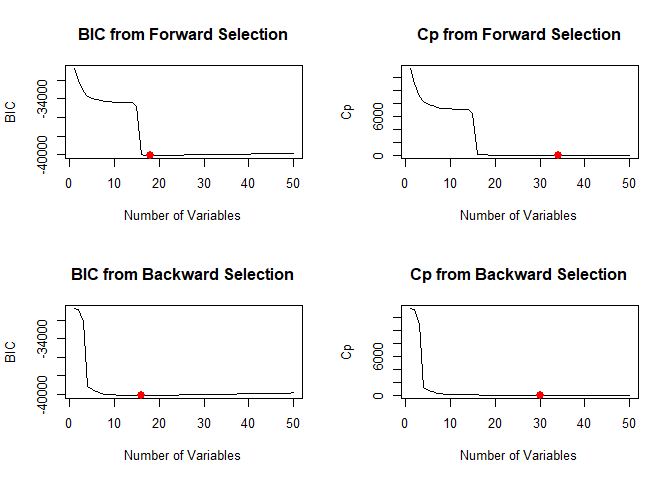

```r
# Subset model
fsub.fit = regsubsets(vannføring~ .-dato -vannstand -modellertvannføring, nvmax = 60, data = train, method="forward")

par(mfrow=c(2,2))

plot(summary(fsub.fit)$bic, xlab = "Number of Variables", ylab = "BIC", type = 'l', main = "BIC from Forward Selection")
l = which.min(summary(fsub.fit)$bic)
points(l, summary(fsub.fit)$bic[l], col="red", cex=2, pch=20)

plot(summary(fsub.fit)$cp, xlab = "Number of Variables", ylab = "Cp", type = 'l', main = "Cp from Forward Selection")
l = which.min(summary(fsub.fit)$cp)
points(l, summary(fsub.fit)$cp[l], col="red", cex=2, pch=20)

bsub.fit = regsubsets(vannføring~ .-dato -vannstand -modellertvannføring, nvmax = 60, data = train, method="backward")

plot(summary(bsub.fit)$bic, xlab = "Number of Variables", ylab = "BIC", type = 'l', main = "BIC from Backward Selection")
l = which.min(summary(bsub.fit)$bic)
points(l, summary(bsub.fit)$bic[l], col="red", cex=2, pch=20)

plot(summary(bsub.fit)$cp, xlab = "Number of Variables", ylab = "Cp", type = 'l', main = "Cp from Backward Selection")
l = which.min(summary(bsub.fit)$cp)
points(l, summary(bsub.fit)$cp[l], col="red", cex=2, pch=20)
```

We choose the covariates with the lowest BIC values from the backward selection.

```r
best = which.min(summary(bsub.fit)$bic)
coeffs = names(coef(bsub.fit, best))[2:length(coef(bsub.fit, best))]
train_subset = subset(train, select = c(coeffs))
train_subset["vannføring"] = train$vannføring

bestsub.fit = lm(vannføring~., data = train_subset)
summary(bestsub.fit)
```

```
##
## Call:
## lm(formula = vannføring ~ ., data = train_subset)
##
## Residuals:
##      Min       1Q   Median       3Q      Max
## -179.008   -1.391    0.067    1.277  263.809
##
## Coefficients:
##                           Estimate Std. Error t value Pr(>|t|)
## (Intercept)             -5.399e-01  1.837e-01  -2.938 0.003304 **
## nedbør                   1.404e+03  1.435e+01  97.820  < 2e-16 ***
## snødekningsgrad          9.451e-03  2.798e-03   3.377 0.000734 ***
## snøvannekvivalent       -1.411e+03  1.685e+01 -83.708  < 2e-16 ***
## temperatur               1.027e-01  1.380e-02   7.437 1.09e-13 ***
## snøvannekvivalent1dager  1.646e+03  3.035e+01  54.229  < 2e-16 ***
## nedbør1dager            -3.542e+02  1.784e+01 -19.857  < 2e-16 ***
## vannføring1dager         7.519e-01  6.344e-03 118.524  < 2e-16 ***
## snøvannekvivalent2dager -1.966e+02  2.170e+01  -9.063  < 2e-16 ***
## nedbør2dager            -5.316e+01  1.255e+01  -4.236 2.29e-05 ***
## temperatur3dager        -8.354e-02  1.369e-02  -6.104 1.06e-09 ***
## vannføring3dager         2.233e-02  5.079e-03   4.397 1.10e-05 ***
## snøvannekvivalent7dager -3.839e+01  4.139e+00  -9.275  < 2e-16 ***
## month_5                  5.043e+00  2.920e-01  17.271  < 2e-16 ***
## month_6                  2.548e+00  2.623e-01   9.716  < 2e-16 ***
## month_9                  1.071e+00  2.425e-01   4.418 1.00e-05 ***
## month_10                 9.789e-01  2.256e-01   4.340 1.44e-05 ***
## ---
## Signif. codes:  0 '***' 0.001 '**' 0.01 '*' 0.05 '.' 0.1 ' ' 1
##
## Residual standard error: 7.141 on 14951 degrees of freedom
## Multiple R-squared:  0.932,  Adjusted R-squared:  0.9319
## F-statistic: 1.281e+04 on 16 and 14951 DF,  p-value: < 2.2e-16
```

```r
bestsub.pred = predict(bestsub.fit, test)
mean((test$vannføring - bestsub.pred)^2)
```

```
## [1] 40.62806
```

Notice that since all the traditional methods are ultimately linear regressions, it is straightforward to obtain inference about the coefficients in the models. As an example, one can easily find confidence intervals by using `confint()`.

The table below gives a summary of the three traditional methods. Notice that the intercept is not included when counting the variables in the last column of the table. Although the weighted linear regression outperforms the others in terms of predictive power, the subset selection is not far behind and have removed many non-significant variables.

| Algorithm | MSE | Adjusted R-squared | Variables |
| --- | --- | --- | --- |
| Linear Regression | 41.13 | 0.932 | 50 |
| Weighted Linear Regression | 38.56 | 0.938 | 50 |
| Subset Selection | 40.63 | 0.932 | 16 |